# All About Measles: A Collaborative Case Study

Authors: Kirsten Casey, Alaina Durant, Taeyeon Kim, and Celia Ligorski

Class: Principles of Epidemiology

Semester: Autumn 2026

## Overview

Measles, sometimes called rubeola (Au et al., *Current Issues in Molecular Biology*, 2026; U.S. Centers for Disease Control and Prevention, 2026), is one of the most contagious known viruses which is spread via respiratory droplets when an infected person breathes, coughs, or sneezes. The virus can remain airborne and active outside the body for up to two hours. An infected person can spread measles from four days before the rash begins until four days afterward (Bester, *JAMA Pediatrics*, 2016; U.S. Centers for Disease Control and Prevention, *Clinical Overview of Measles*, 2026). Measles most commonly affects children, but it can be spread to anyone who is not immune; an estimated 90% of non-immune people who come in contact with an infected person will contract the disease (U.S. Centers for Disease Control and Prevention, 2026). Vaccination is the best way to protect oneself and others from measles infection.

In the United States, measles was declared eliminated in 2000, but it remains endemic in Africa, Southeast Asia, the Eastern Mediterranean, and the Western Pacific regions as defined by the World Health Organization (WHO) (Mohamedosman et al., *Italian Journal of Pediatrics*, 2026). Measles outbreaks in the United States can still occur when people (often Americans) travel into the country, particularly if they have come in contact with under- or unvaccinated communities. In recent years, outbreaks in the United States have become more common, driven predominantly by vaccine hesitancy (Bester, *JAMA Pediatrics*, 2016; Mohamedosman et al., *Italian Journal of Pediatrics*, 2026).

## Symptoms & Diagnosis

• Timeline  
• Symptoms  
• Diagnosis

##### Timeline

After exposure, there is an incubation period of about **10–14 days (range 7–21)** before the first symptoms appear (Stoneman, *JAMA*, 2025).

##### Symptoms

**The prodrome (“the 3 Cs”).** Illness begins with a 2–4 day period of high fever plus **cough, coryza (runny nose), and conjunctivitis (red, watery eyes)** — the classic “three Cs.” Fever can climb above 40 °C (104 °F). The conjunctivitis is often severe, with tearing and sensitivity to light (Naureckas Li et al., *Pediatrics*, 2025; Do & Mulholland, *New England Journal of Medicine*, 2025).

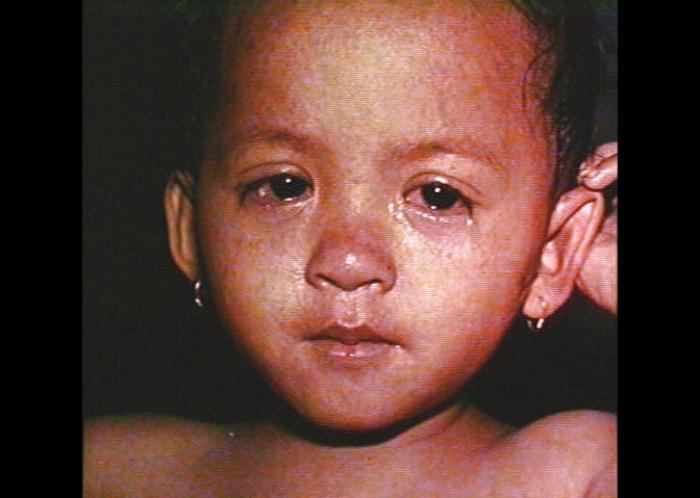

**Koplik spots.** During the prodrome, tiny white or bluish-white spots on a red background may appear inside the cheeks (buccal mucosa). These **Koplik spots are pathognomonic** — meaning they are unique to measles — but they are easy to miss because they last only 1–3 days and most people do not seek care that early (Rota et al., *Nature Reviews Disease Primers*, 2016; Naureckas Li et al., *Pediatrics*, 2025).

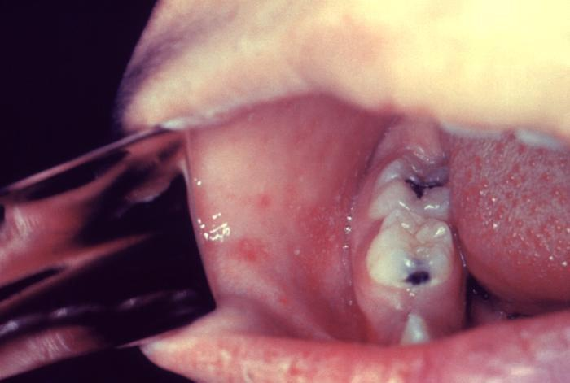

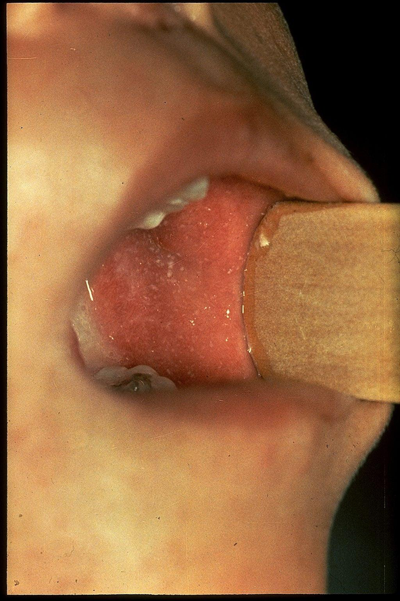

**The rash.**

- The rash is first noticed around 2–4 days after the fever starts (roughly 14 days after exposure).
- It is characterized as a **red, blotchy, maculopapular rash**. It starts at the hairline and behind the ears, then spreads downward to the face, trunk, arms, and legs. It typically begins bright red and blanching, then turns coppery-brown, and often peels (desquamates) as it fades in the same order it appeared.
- The rash usually lasts about a week; the cough can linger longer than 10 days (Naureckas Li et al., *Pediatrics*, 2025; Goodson & Filardo, *CDC Yellow Book*, 2025).

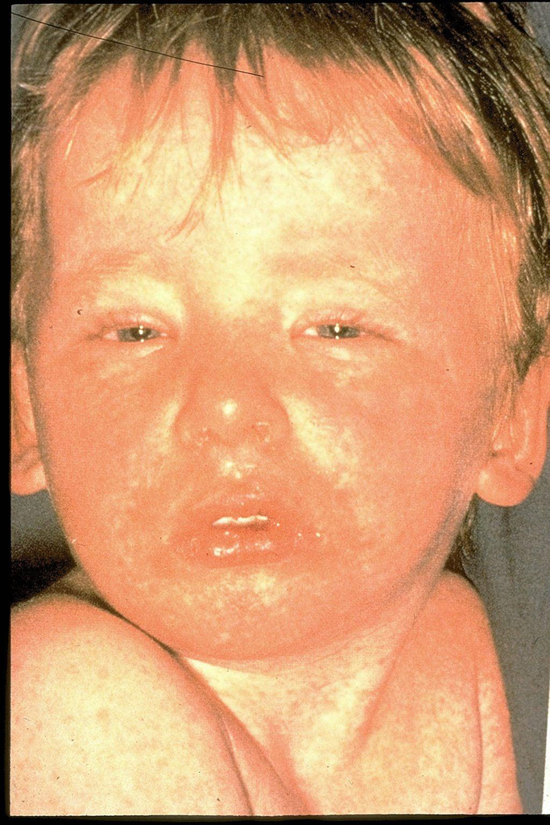

[figure not shown]

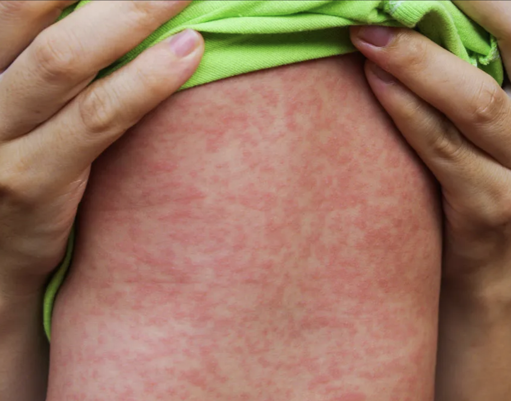

##### Diagnosis

**When to suspect measles?** Measles should be considered in anyone with **fever plus a rash**, especially if they are unvaccinated, have recently traveled internationally or to a U.S. area with a known outbreak, or had a known exposure within the past 21 days (Stoneman, *JAMA*, 2025).

**Diagnosis process.** Clinical suspicion must be confirmed by laboratory testing:

- RT-PCR (reverse transcriptase-polymerase chain reaction) from a throat or nasopharyngeal swab is the preferred test; adding a urine sample increases sensitivity. Specimens should be collected as soon as measles is suspected. RNA detection is most successful in samples collected from the day the rash begins through day 3, although RT-PCR may still detect measles RNA 10–14 days after rash onset (U.S. Centers for Disease Control and Prevention, *Laboratory Testing for Measles*, 2024). The test has a sensitivity of ~94% and a specificity of ~99% (Stoneman, *JAMA*, 2025; Naureckas Li et al., *Pediatrics*, 2025).
- Serum measles-specific IgM antibody is typically detectable 3–30 days after rash onset. It should also be noted that measles-specific IgG appears later and indicates immunity from past infection or vaccination (Stoneman, *JAMA*, 2025).

**A key point:** any suspected case should prompt an immediate call to the local health department and hospital infection prevention team for guidance on testing and isolation, because there is no rapid point-of-care test — samples must be sent to a lab (Stoneman, *JAMA*, 2025).

## Transmission & Surveillance

• Transmission  
• Spread  
• Surveillance  
• Socioeconomic Factors

The basic reproductive number, **R<sub>0</sub>**, is used as a **measure of transmissibility**, representing the expected number of individuals to whom an infected person will spread a given disease assuming no immunity.

##### R<sub>0</sub> for Measles and Common Viruses:

- **Human rhinovirus or “common cold”** (Morelli et al., *Respiratory Research*, 2025): R<sub>0</sub> ~ 1.2-2.6
- **Seasonal flu** (Biggerstaff et al., *BMC Infectious Disease*, 2014): R<sub>0</sub> ~ 2-3
- **COVID-19** (Liu et al., *Journal of Travel Medicine*, 2020): R<sub>0</sub> ~ 3.3
- **Measles** (Mohamedosman et al., *Italian Journal of Pediatrics*, 2026): R<sub>0</sub> ~ 12-18

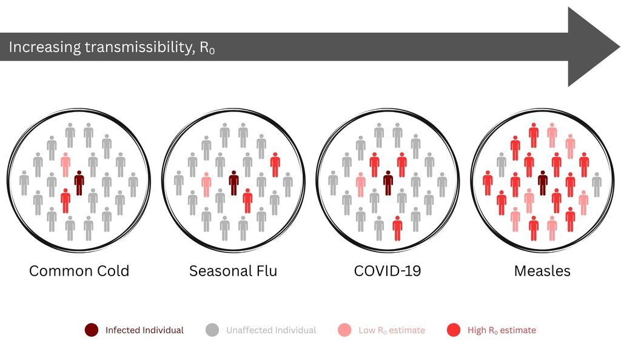

##### Spread

Transmission of measles can be interrupted and the effective R<sub>0</sub> can be reduced if enough people in a population are immune; because measles is so contagious, **95% of people in a community must be fully vaccinated to control further spread** (Au et al., *Current Issues in Molecular Biology*, 2026; Bester, *JAMA Pediatrics*, 2016; Mohamedosman et al., *Italian Journal of Pediatrics*, 2026).

The WHO estimated that, globally, approximately 77% of children received both recommended doses of the MMR vaccine in 2025, while 84% received at least the first dose. The WHO also maintains immunization partnerships with local organizations across all regions of the world to work toward the goal of measles elimination (World Health Organization, 2026).

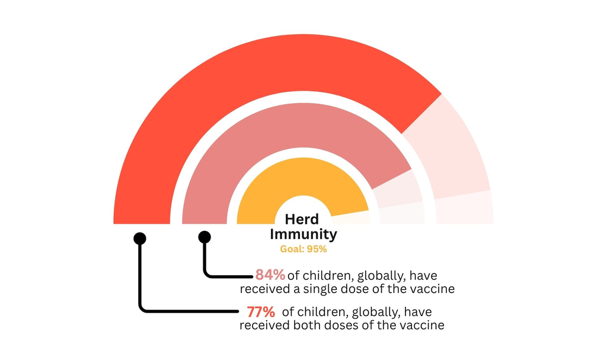

##### Surveillance in the United States

In the United States, measles is a **notifiable disease**, meaning confirmed or suspected cases should be reported to the local health department as soon as possible to support public health investigations.

**Investigative responses to measles outbreaks involve the following:**

- Vaccination campaigns
- Contact tracing
- Isolation of infected individuals.

Many factors influence the effectiveness of measles surveillance and elimination efforts in the United States; in particular, the COVID-19 pandemic interrupted planned vaccination and surveillance campaigns and exacerbated vaccine hesitancy and refusal. As a result, the United States and other regions around the world are experiencing more frequent outbreaks and caseloads in recent years.

Vaccine campaigns over the years:

[figure not shown]

[figure not shown]

[figure not shown]

Image sources, left to right: [Science Museum Group Collection](https://collection.sciencemuseumgroup.org.uk/search/objects/object_type/measles); [Science Museum Group Collection](https://collection.sciencemuseumgroup.org.uk/objects/co8093234/give-your-child-something-you-never-had); [City of Philadelphia](https://vaccines.phila.gov/wp-content/uploads/2024/08/measles-flyer-Eng-1.jpg).

Contact Tracing:

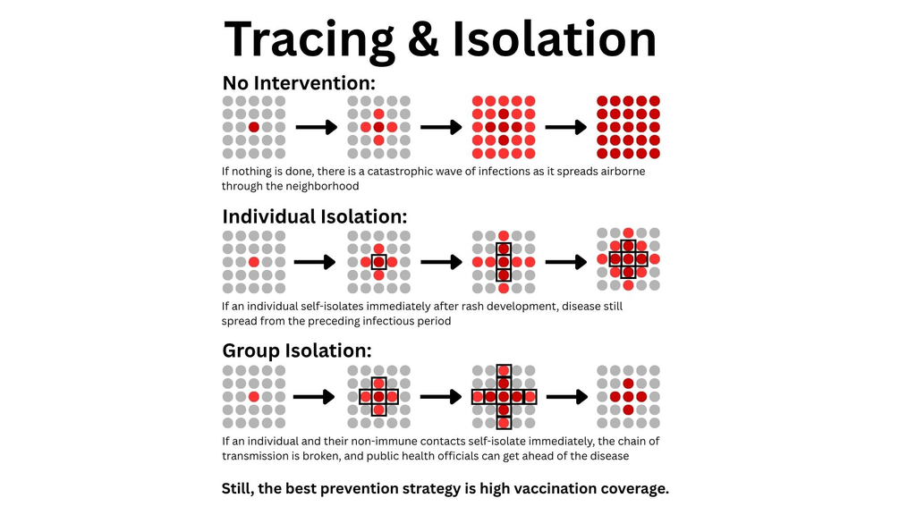

##### Socioeconomic Factors Affecting Spread and Surveillance

Socioeconomic factors play a significant role in the ability of public health officials to respond to outbreaks and are correlated with increased risk of measles infection and worse outcomes; these include (Mohamedosman et al., *Italian Journal of Pediatrics*, 2026):

- Crowded or uncertain living conditions
- Low educational attainment
- Lack of access to sufficient healthcare

## Treatment & Prevention

• Treatment  
• Prevention  
• After an Exposure  
• During an Active Outbreak

##### Treatment

**There is no specific antiviral treatment for measles.** Care is *supportive*. It focuses on managing fever, maintaining hydration, and encouraging rest, while watching for and treating complications as they arise. Prevention measures are also important as the best treatment is avoidance of the disease altogether.

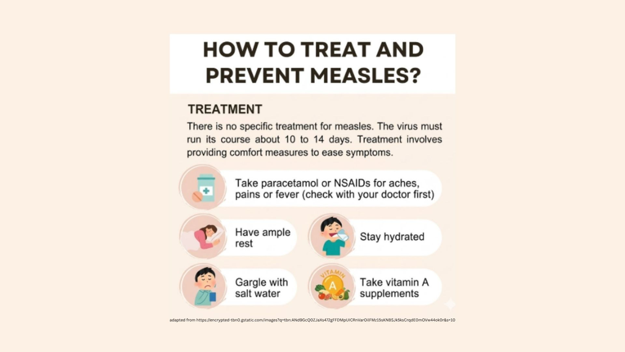

For infants and children with measles, a healthcare provider may recommend vitamin A as part of supportive care. It should be given only under medical supervision. Vitamin A is not a way to prevent measles or an alternative to vaccination, and excessive intake can be harmful (U.S. Centers for Disease Control and Prevention, *Clinical Overview of Measles*, 2026).

##### Prevention

**The best prevention is the MMR vaccine.** One dose is 95% effective at preventing measles and 92% effective at preventing spread to household contacts. When the first dose is given at 12 months or older, 95% of children develop immunity. With a second dose, more than 99% develop immunity (Bester, 2016). In the United States, the CDC recommends the first dose at 12 to 15 months of age and the second dose at 4 to 6 years. Doses given before 12 months do not count as valid doses. To stop measles from spreading in a community, 93% to 95% of the population needs to be immune, making it important for two-dose vaccination coverage to stay at or above that range. Common side effects of the vaccine, such as fever or a mild rash, are mild and go away on their own. Serious side effects are very rare (Bester, 2016).

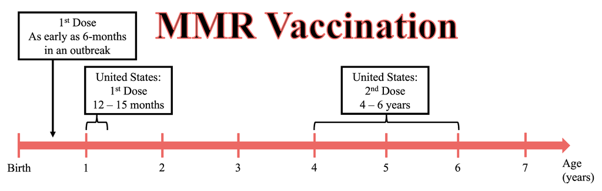

##### After an Exposure

If a person who is not immune is exposed to measles, the MMR vaccine can still be given within 72 hours of exposure, and immune globulin can be given within 6 days of exposure. This has been supported with clinical evidence as seen in a 2022 central Ohio outbreak; 59 exposed contacts received one of these, and none of the 51 who received immune globulin developed measles (Tiller et al., 2023).

##### During an Active Outbreak

- **For families:** Check your MMR status now. A dose given within 72 hours of a known exposure can still prevent illness.
- **For the public**: Call ahead before walking into a clinic or ED with suspected measles, don’t just show up.
- **For providers**: Think measles in any child with fever and rash, and report it the same day you suspect it. Patients are contagious before the rash ever appears.

## The MMR Vaccine: Myths vs. Facts

##### The MMR Vaccine Myths vs. Facts

**Myth 1: “The MMR vaccine causes autism.”**

**Fact:** It does not. This claim came from a single 1998 paper that was **retracted for fraud**, and its author lost his medical license. Since then, studies of **millions** of children have found **no link**. A nationwide study of 657,461 children found no increased autism risk in vaccinated children (hazard ratio 0.93), and a Cochrane review of the combined evidence reached the same conclusion (Hviid et al., *Annals of Internal Medicine*, 2019; Di Pietrantonj et al., *Cochrane Database of Systematic Reviews*, 2021).

**Myth 2: “Mercury (thimerosal) in the MMR shot is dangerous.”**

**Fact:** The MMR vaccine has **never contained thimerosal** or any mercury preservative. Separately, the type of mercury once used in a few other vaccines (ethylmercury) is cleared by the body quickly and is not the harmful kind (methylmercury). Expert reviews found **no link** between thimerosal and autism (Larson et al., *New England Journal of Medicine*, 2022; Committee on Infectious Diseases, American Academy of Pediatrics, 2024).

**Myth 3: “Aluminum or ‘fetal cells’ in vaccines are harmful.”**

**Fact:** The MMR vaccine does **not** contain aluminum. Some vaccine viruses, including the rubella component of MMR, are grown in laboratory cell lines originally derived from fetal tissue. The finished vaccines do not contain fetal tissue or intact fetal cells, although tiny amounts of fragmented DNA or protein from the production cells may remain after purification (Children’s Hospital of Philadelphia, *Vaccine ingredients: Fetal cells*, 2026). Where aluminum is used as an adjuvant in other vaccines, the amount is tiny, regulated, and similar to what infants take in through breast milk or formula (Committee on Infectious Diseases, American Academy of Pediatrics, 2024; O’Leary et al., *Pediatrics*/AAP, 2024).

**Myth 4: “It’s safer to space out shots or give them one at a time.”**

**Fact:** There is **no benefit** to splitting the combination MMR into separate shots, and doing so only prolongs the time a child is unprotected. A child’s immune system easily handles the antigens in routine vaccines alongside the countless germs it meets every day (U.S. Centers for Disease Control and Prevention, 2024; Committee on Infectious Diseases, American Academy of Pediatrics, 2024).

**Myth 5: “Natural infection gives better immunity than the vaccine.”**

**Fact:** “Natural” measles immunity comes at a steep price: pneumonia, brain inflammation, and death are all possible, and measles can wipe out the immune system’s memory for years (“immune amnesia”), leaving a child vulnerable to other infections. Even complications like low-platelet bleeding (ITP) are **more common after natural infection than after the vaccine** (Do & Mulholland, *New England Journal of Medicine*, 2025; Di Pietrantonj et al., *Cochrane Database of Systematic Reviews*, 2021).

**Myth 6: “The vaccine is more dangerous than the disease.”**

**Fact:** Serious reactions to MMR are **very rare**. Mild effects (sore arm, brief fever, mild rash) are common. MMR vaccination is associated with a small increase in febrile seizures, affecting about 1 in 3,000–4,000 vaccinated children. These seizures are not associated with long-term effects (U.S. Centers for Disease Control and Prevention, 2024). By contrast, measles itself kills 1–3 of every 1,000 people infected and causes complications in up to about 30% of cases (McLean et al., 2013; Stoneman, *JAMA*, 2025; Do & Mulholland, *New England Journal of Medicine*, 2025).

**Myth 7: “Measles is just a harmless childhood rash.”**

**Fact:** Measles can be severe. Complications include ear infections and hearing loss, pneumonia (the leading cause of measles death), encephalitis (about 1 per 1,000–2,000 cases), and the rare, always-fatal (fatal in 100% of patients) brain disease SSPE years later. Infants, pregnant people, and immunocompromised people are at highest risk (Stoneman, *JAMA*, 2025; Do & Mulholland, *New England Journal of Medicine*, 2025).

**The bottom line:** Two doses of MMR are about 97% effective and have a decades-long safety record. Vaccination protects your child and the people around them who can’t be vaccinated — newborns and those with weakened immune systems (Gastañaduy et al., *Journal of Infectious Diseases*, 2021; Stoneman, *JAMA*, 2025).

## Provider: When a Patient Has Measles

##### Identify, Isolate, Inform

- **Think of measles early.** Suspect measles in any patient, especially in those patients w/ unknown or incomplete vaccination status who presents with fever ≥38.3°C (101°F) plus cough, coryza, or conjunctivitis, and a generalized maculopapular rash. Suspicion should rise further with recent travel to an outbreak area, a known exposure, or residence in a community with under-vaccinated pockets, even if the broader region’s coverage looks adequate on paper. Do not wait for the rash or koplik spots.
- **Isolate immediately.** *Isolate on suspicion, not on confirmation.* Place the suspected patient in airborne isolation and mask the patient. The virus can linger in the air for up to 2 hours, a suspected case in a busy waiting room can expose MANY many vulnerable people. Patients are shedding the virus before they, or you, know they’re infected. Ask families who suspect measles to call ahead rather than walking into a crowded ED or clinic.
- **Inform and Coordinate.** Notify the local or state health department and infection prevention team as soon as measles is suspected - *before* the test returns. Measles is a nationally notifiable disease. A day or two of delay can close the window for effective contact tracing and post-exposure prophylaxis. Offer post-exposure prophylaxis to identified contacts: MMR vaccine within 72 hours of exposure, or immune globulin within 6 days, prioritizing infants, pregnant patients, and immunocompromised contacts who cannot receive the live vaccine.
- **Confirm with Testing.** Test with nasopharyngeal/throat PCR (highly sensitive, and allows genotyping to link cases during an outbreak) and/or serum IgM.
- **Protect your waiting room.** Screen for fever, rash, travel, and vaccine status before a patient enters common space, and give patients/families a way to call ahead if they suspect measles. In the 2022–2023 central Ohio outbreak, 38% of exposures occurred inside healthcare facilities — more than in households or child care settings — because the first cases weren’t recognized before they reached a waiting room (Tiller et al., 2023).

## Provider: How to Counsel Families

##### How to communicate and counsel families about measles effectively

- Lead with curiosity and listening, not correction or lecturing.
  - Ask open, non judgmental questions to understand each family’s concerns, what they’ve read or heard, and where, before responding. Understanding the real concern lets you address it directly.
  - Ask about the reasons behind the hesitancy, not just the myths. Cultural, religious, or access barriers call for a different conversation than misinformation does — and pointing families toward sources they already trust works better than only offering your own.
- Skip the scare tactics. Rather make the risk concrete and personal.
  - Explain that the measles is not a mild illness- it can cause pneumonia, brain inflammation and death and it can suppress the immune system for years. (Stoneman, *JAMA*, 2025; Do & Mulholland, *New England Journal of Medicine*, 2025).
  - Reviews of vaccine-communication strategies have found that graphic images, dramatic anecdotes, and dire warnings can backfire and entrench resistance rather than change minds. Speaking with total certainty can have the same effect (Whitehead et al., 2023).
- “Pre-bunk” when you can.
  - Giving families accurate information before they encounter misinformation is more effective than trying to correct it afterward (Whitehead et al., 2023).
- Address the autism claim clearly and calmly.
  - The claim that the MMR vaccine causes autism originated in 1998 paper, an uncontrolled, single, small (12-child) study that was later retracted for fraud and its author lost his medical license. Numerous large, multi-center studies have since been completed that have found NO LINK between MMR and Autism. A Cochrane review of the much larger body of research published since found no association.
- Be honest about real side effects.
  - They exist — typically mild and self-limited fever, rash, or joint pain — and serious reactions are rare. Minimizing legitimate safety questions undermines trust more than it reassures.
- Acknowledge the choice to vaccinate, every time.
  - A brief “thank you for protecting your community” costs nothing and can ease the discomfort many families feel even bringing the topic up.
  - Frame vaccination as protecting the whole community. Vaccination projects not only the child but infants, too young to be vaccinated and immunocompromised neighbors who depend on herd immunity (95% vaccination).
- Build the relationship before the crisis.
  - Trust formed over routine visits is what a family draws on when they’re deciding whether to believe you in the middle of an outbreak.

## Outbreak Tracker

• Local  
• National  
• Global

### Local

#### Confirmed Measles Cases in Ohio (2026)

[interactive chart not shown]

#### Yearly Reported Measles Cases in Ohio, 2020-2026

[interactive chart not shown]

#### MMR Vaccine Coverage Among Ohio Kindergarteners, 2024-2025

[interactive chart not shown]

**Source:** Ohio Department of Health (ODH), Ohio Immunization Program and Ohio measles surveillance data (https://odh.ohio.gov/). County-level measles cases were obtained through the ODH surveillance system/ArcGIS dashboard. Kindergarten MMR vaccination coverage was obtained from ODH annual school immunization reporting data for the 2024–2025 school year. Data downloaded September 18, 2026.

### National

As of September 10, 2026, there have been **3,294 confirmed measles cases** in the United States among 47 states. This has incorporated 38 separate outbreaks, with 3,123 of the cases being diagnosed as a direct result of a local outbreak. A total of 16 measles cases were reported among international visitors to the US.

#### Confirmed Measles Cases Among U.S. Residents, 2024-2026

[interactive chart not shown]

#### Monthly Reported Measles Cases in the United States, Jan 2022 - Sept 2026

[interactive chart not shown]

#### Yearly Reported Measles Cases in the United States, 1985-2026

[interactive chart not shown]

#### MMR Vaccine Coverage for Kindergarteners by School Year, 2009-2026

[interactive chart not shown]

**Source:** U.S. Centers for Disease Control, CDC Surveillance Index (https://www.cdc.gov/measles/data-research/index.html). Measles Cases and Outbreaks as reported to the National Center for Immunization and Respiratory Diseases (NCIRD), Division of Viral Diseases (DVD). Published May 15, 2024. Updated and reviewed September 11, 2026. Data downloaded September 18, 2026.

### Global

#### Reported measles cases worldwide, 1980–2025

[interactive chart not shown]

#### Measles vaccine coverage worldwide, first and second dose, 1980–2025

[interactive chart not shown]

#### Reported measles incidence by country (select a year)

[interactive chart not shown]

#### Measles vaccine coverage by country, 2025 (select first or second dose)

[interactive chart not shown]

**Data source:** World Health Organization, WHO Immunization Data Portal (immunizationdata.who.int). Reported measles cases and incidence as reported by national authorities to WHO; vaccination coverage from the WHO/UNICEF Estimates of National Immunization Coverage (WUENIC), 2025 revision. Data downloaded September 18, 2026.

Notes: Reported cases depend on each country’s surveillance and reporting, so they undercount true cases, and some countries did not report in some years (shown in gray). WHO calculates global and regional incidence using only the countries that reported data for that year. Coverage values are WHO/UNICEF estimates, which can differ from coverage reported by countries. Country boundaries come from Plotly’s world map, not from WHO.

## References

##### Sources used for creation of this tool

Au S., Saini S., Cruz W.D., & Venketaraman V. (2026). Measles: An Updated Literature Review of the Host Response, Pathogenesis, Complications, Prevention Measures, and Recent Outbreaks. *Current Issues in Molecular Biology, 48*(2):206. doi:10.3390/cimb48020206

Balu B., & Mostow E. N. (2019). Measles. *JAMA dermatology, 155*(12), 1436. doi:10.1001/jamadermatol.2019.2663

Biggerstaff M., Cauchemez S., Reed C., Gambhir M., & Finelli L. (2014). Estimates of the reproduction number for seasonal, pandemic, and zoonotic influenza: a systematic review of the literature. *BMC Infectious Diseases, 14*:480. doi:10.1186/1471-2334-14-480

Bester J.C. (2016). Measles and Measles Vaccination: A Review. *JAMA Pediatrics, 170*(12):1209-1215. doi:10.1001/jamapediatrics.2016.1787

Children’s Hospital of Philadelphia, Vaccine Education Center. (2026, September 9). *Vaccine ingredients: Fetal cells*. https://www.chop.edu/vaccine-education-center/vaccine-safety/vaccine-ingredients/fetal-tissues

Committee on Infectious Diseases, American Academy of Pediatrics. (2024). *Red Book: 2024–2027 Report of the Committee on Infectious Diseases* (D. W. Kimberlin, R. Banerjee, E. D. Barnett, R. Lynfield, & M. H. Sawyer, Eds.). American Academy of Pediatrics. doi:10.1542/9781610027373

Di Pietrantonj C., Rivetti A., Marchione P., Debalini M. G., & Demicheli, V. (2021). Vaccines for measles, mumps, rubella, and varicella in children. *The Cochrane Database of Systematic Reviews, 11*(11), CD004407.

Do L. A. H., & Mulholland K. (2025). Measles 2025. *The New England Journal of Medicine, 393*(24), 2447–2458. doi:10.1056/NEJMra2504516

Gastañaduy P. A., Goodson J. L., Panagiotakopoulos L., Rota P. A., Orenstein W. A., & Patel M. (2021). Measles in the 21st Century: Progress Toward Achieving and Sustaining Elimination. *The Journal of Infectious Diseases, 224*(12 Suppl 2), S420–S428. doi:10.1093/infdis/jiaa793

Gershon A. A., Edwards K., Orenstein W., & Schaffner W. (2020). Freedom, Measles, and Freedom from Measles. *The New England Journal of Medicine, 382*(11), 983–985. doi:10.1056/NEJMp2000807

Goodson J. L., & Filardo T. D. (2025). Measles (Rubeola). In E. S. Halsey (Eds.) et. al., *CDC Yellow Book, 2026 edition: Health Information for International Travel.* Centers for Disease Control and Prevention (US).

Hviid A., Hansen J. V., Frisch M., & Melbye M. (2019). Measles, Mumps, Rubella Vaccination and Autism: A Nationwide Cohort Study. *Annals of Internal Medicine, 170*(8), 513–520. doi:10.7326/M18-2101

Larson H. J., Gakidou E., & Murray C. J. L. (2022). The Vaccine-Hesitant Moment. *The New England Journal of Medicine, 387*(1), 58–65. doi:10.1056/NEJMra2106441

Liu Y., Gayle A. A., Wilder-Smith A., & Rocklöv J. (2020). The reproductive number of COVID-19 is higher compared to SARS coronavirus. *Journal of Travel Medicine, 27*(2):taaa021. doi:10.1093/jtm/taaa021

McLean H. Q., Fiebelkorn A. P., Temte J. L., Wallace G. S., & Centers for Disease Control and Prevention (2013). Prevention of measles, rubella, congenital rubella syndrome, and mumps, 2013: Summary recommendations of the Advisory Committee on Immunization Practices (ACIP). *MMWR. Recommendations and reports, 62*(RR-04), 1–34.

Misin A., Antonello R. M., Di Bella S., Campisciano G., Zanotta N., Giacobbe D. R., Comar M., & Luzzati R. (2020). Measles: An Overview of a Re-Emerging Disease in Children and Immunocompromised Patients. *Microorganisms, 8*(2):276. doi:10.3390/microorganisms8020276

Mohamedosman E. H. A., Ullah M. F., Alnour T. M. S., Elssaig E. H., Yousif A., & Holie M. I. (2026). Measles challenges: global resurgence and factors affecting eradication. *Italian Journal of Pediatrics, 52*(1):123. doi:10.1186/s13052-026-02283-w

Morelli T., Freeman A., Staples K. J., & Wilkinson T. M. A. (2025). Hidden in plain sight: the impact of human rhinovirus infection in adults. *Respiratory Research, 26*(1), 120. doi:10.1186/s12931-025-03178-w

Moss W. J. (2017). Measles. *Lancet (London, England), 390*(10111), 2490–2502. doi:10.1016/S0140-6736(17)31463-0

Naureckas Li C., Kaplan S. L., Edwards K. M., Marshall G. S., Parker S., & Mary Healy C. (2025). What’s Old Is New Again: Measles. *Pediatrics, 155*(6), e2025071332. doi:10.1542/peds.2025-071332

O’Leary S. T., Opel D. J., Cataldi J. R., Hackell J. M., Committee on Infectious Diseases, Committee on Practice and Ambulatory Medicine, & Committee on Bioethics. (2024). Strategies for Improving Vaccine Communication and Uptake. *Pediatrics, 153*(3), e2023065483. doi:10.1542/peds.2023-065483

Plans-Rubió P. (2025). Measles Vaccination Coverage and Anti-Measles Herd Immunity Levels in the World and WHO Regions Worsened from 2019 to 2023. *Vaccines, 13*(2):157. doi:10.3390/vaccines13020157

Robert A., Kucharski A. J., & Funk S. (2022). The impact of local vaccine coverage and recent incidence on measles transmission in France between 2009 and 2018. *BMC Medicine, 20*(1), 77. doi:10.1186/s12916-022-02277-5

Rota P. A., Moss W. J., Takeda M., de Swart R. L., Thompson K. M., & Goodson J. L.(2016). Measles. *Nature Reviews Disease Primers, 2,* 16049. doi:10.1038/nrdp.2016.49

Salhotra P., & Carver J. L. (2025, April 6). A second Texas child has died from measles; RFK Jr. visits. *The Texas Tribune*. Accessed September 4, 2026.

Stoneman E. K. (2025). Measles. *JAMA,* Advance online publication. doi:10.1001/jama.2025.14210

Tiller E. C., Masters N. B., Raines K. L., Mathis A. D., Crooke S. N., Zwickl R. C., French G. K., Alexy E. R., Koch E. M., Tucker N. E., Wilson E. M., Krauss T. S., Leasure E., Budd J., Billing L. M., Dewart C., Tarter K., Dickerson K., Iyer R., … Roberts, M. W. (2023). Notes from the Field: Measles Outbreak - Central Ohio, 2022-2023. *MMWR. Morbidity and Mortality Weekly Report, 72*(31), 847–849. doi:10.15585/mmwr.mm7231a3

U.S. Centers for Disease Control and Prevention. (2024, June 12). *Laboratory Testing for Measles*. https://www.cdc.gov/measles/php/laboratories/index.html

U.S. Centers for Disease Control and Prevention. (2024, July 31). *Measles, Mumps, Rubella (MMR) Vaccine Safety*. https://www.cdc.gov/vaccine-safety/vaccines/mmr.html

U.S. Centers for Disease Control and Prevention. (2026, April 29). *About Measles (Rubeola)*. https://www.cdc.gov/measles/about/index.html

U.S. Centers for Disease Control and Prevention. (2026, August 5). *Clinical Overview of Measles*. https://www.cdc.gov/measles/hcp/clinical-overview/index.html

Walter K., & Malani P. N. (2022). What Is Measles? *JAMA, 328*(23), 2370. doi:10.1001/jama.2022.21363

Whitehead H. S., French C. E., Caldwell D. M., Letley L., Mounier-Jack S. (2023). A systematic review of communication interventions for countering vaccine misinformation. *Vaccine, 41*(5), 1018-1034. doi:10.1016/j.vaccine.2022.12.059

World Health Organization. (2026). *Measles*. https://www.who.int/health-topics/measles